# Basic Graphics in R

Rodney Dyer, PhD

## Topics

- Background
- Univariate Data
- Bivariate Data
- Categorical Data
- Text & Customization

## How most learn graphics

## The Example Data - Iris

There is a classic data set in statistics called *Fisher’s Iris Data Set* looking at 50 measurements of *sepal* and *pedal* lengths among three species of *Iris* <sup>1</sup>.

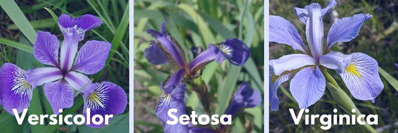

[^1]: These data were first published in Fisher RA (1936) The use of multiple measurements in taxonomic problems. *Annals of Eugenics*, **7**: [doi](https://onlinelibrary.wiley.com/doi/abs/10.1111/j.1469-1809.1936.tb02137.x).

## Anatomy of a Flower

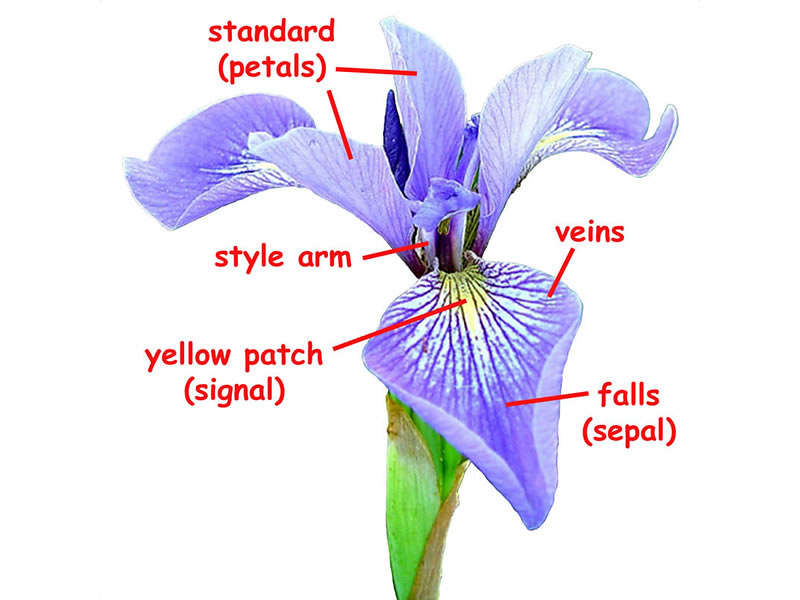

Iris morphology

## The Example Data - Iris

|  | Sepal.Length | Sepal.Width | Petal.Length | Petal.Width | Species |
| --- | --- | --- | --- | --- | --- |
| 1 | 5.1 | 3.5 | 1.4 | 0.2 | setosa |
| 2 | 4.9 | 3 | 1.4 | 0.2 | setosa |
| 3 | 4.7 | 3.2 | 1.3 | 0.2 | setosa |
| 4 | 4.6 | 3.1 | 1.5 | 0.2 | setosa |
| 5 | 5 | 3.6 | 1.4 | 0.2 | setosa |
| 6 | 5.4 | 3.9 | 1.7 | 0.4 | setosa |
| 7 | 4.6 | 3.4 | 1.4 | 0.3 | setosa |
| 8 | 5 | 3.4 | 1.5 | 0.2 | setosa |
| 9 | 4.4 | 2.9 | 1.4 | 0.2 | setosa |
| 10 | 4.9 | 3.1 | 1.5 | 0.1 | setosa |

[output cut: 140 more lines]

## The Example Data - Iris

```r
summary( iris )
```

```
  Sepal.Length    Sepal.Width     Petal.Length    Petal.Width
 Min.   :4.300   Min.   :2.000   Min.   :1.000   Min.   :0.100
 1st Qu.:5.100   1st Qu.:2.800   1st Qu.:1.600   1st Qu.:0.300
 Median :5.800   Median :3.000   Median :4.350   Median :1.300
 Mean   :5.843   Mean   :3.057   Mean   :3.758   Mean   :1.199
 3rd Qu.:6.400   3rd Qu.:3.300   3rd Qu.:5.100   3rd Qu.:1.800
 Max.   :7.900   Max.   :4.400   Max.   :6.900   Max.   :2.500
       Species
 setosa    :50
 versicolor:50
 virginica :50
```

# Univariate Data

## A Single Vector of Data

```r
sepal_length <- iris$Sepal.Length
head(sepal_length)
```

```
[1] 5.1 4.9 4.7 4.6 5.0 5.4
```

## A Single Vector of Data - Histograms

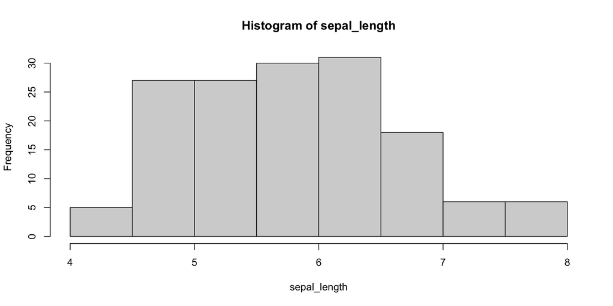

```r
hist( sepal_length )
```

## Arguments to Customize Plots

- `xlab` & `ylab`: The names attached to both x- and y-axes.
- `main`: The title on top of the graph.
- `breaks`: This controls the way in which the original data are partitioned (e.g., the width of the bars along the x-axis).
  - If you pass a single number, `n` to this option, the data will be partitioned into `n` bins.
  - If you pass a sequence of values to this, it will use this sequence as the boundaries of bins.
- `col`: The color of the bar (not the border)
- `probability`: A flag as either `TRUE` or `FALSE` (the default) to have the y-axis scaled by total likelihood of each bins rather than a count of the numbrer of elements in that range.

## Density Plots

```r
d_sepal.length <- density( sepal_length )
d_sepal.length
```

```
Call:
    density.default(x = sepal_length)

Data: sepal_length (150 obs.);  Bandwidth 'bw' = 0.2736

       x               y
 Min.   :3.479   Min.   :0.0001495
 1st Qu.:4.790   1st Qu.:0.0341599
 Median :6.100   Median :0.1534105
 Mean   :6.100   Mean   :0.1905934
 3rd Qu.:7.410   3rd Qu.:0.3792237
 Max.   :8.721   Max.   :0.3968365
```

```r
class(d_sepal.length)
```

```
[1] "density"
```

# Density Plots

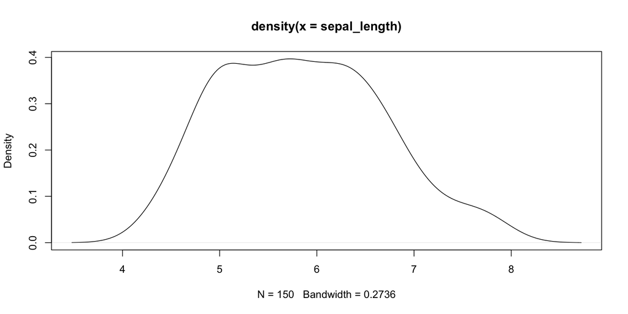

```r
plot( d_sepal.length )
```

# Bivariate Data

## The Generality of `plot()`

In `R`, many objects understand how to `plot` themselves.

- Density objects
- Analyses (regression, ANOVA, etc)
- points, lines, polygons, & rasters

## A Scatter Plot

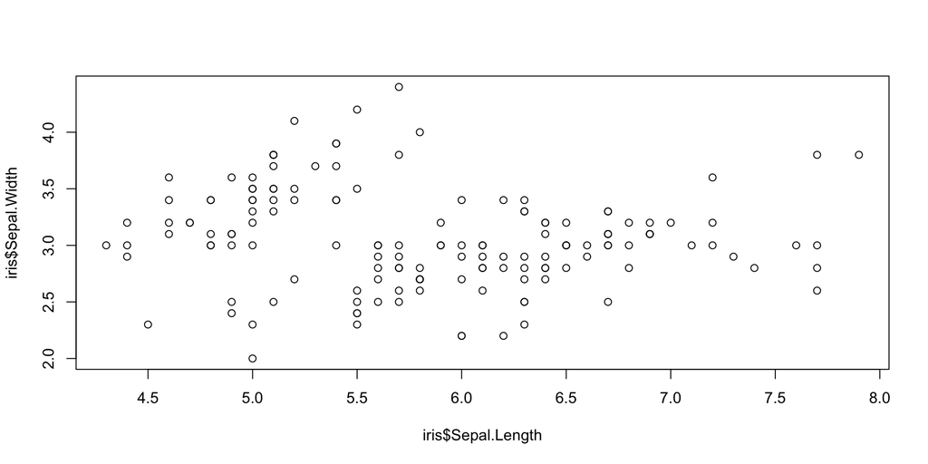

```r
plot( iris$Sepal.Length, iris$Sepal.Width )
```

## Functional Forms

Plotting of two vectors of data, the first position is on the x-axis and the second is on the y-axis.

```r
plot( x, y )
```

A more *functional* form of the same plot but designed as a formula where *y is a function of x*.

```r
plot( y ~ x)
```

This is consistent with how we will specify analyses (regression, anova, etc.).

# Customizing Plots

## `plot()` Options

| Parameter | Description |
| --- | --- |
| `type` | The kind of plot to show (’p’oint, ’l’ine, ’b’oth, or ’o’ver). A point plot is the default. |
| `pch` | The character (or symbol) being used to plot. There 26 recognized general characters to use for plotting. The default is `pch=1`. |
| `col` | The color of the symbols/lines that are plot. |
| `cex` | The magnification size of the character being plot. The default is `cex=1` and deviation from that will increase (cex > 1) or decrease (0 < cex < 1) the scaling of the symbols. Also works for `cex.lab… |
| `lwd` | The width of any lines in the plot. |
| `lty` | The type of line to be plot (solid, dashed, etc.) |
| `bty` | The ‘Box’ type around the plot (“o”, “1”, “7”,“c”,“u”, “]”, and my favorite “n”) |

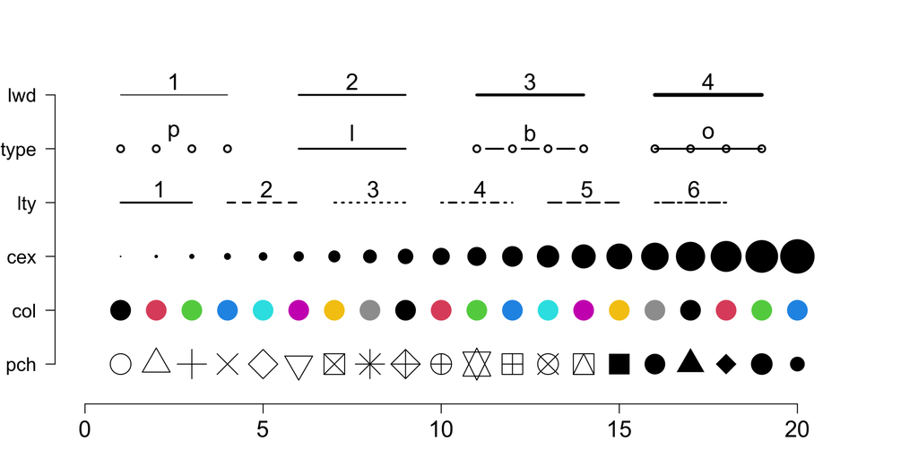

## Species Differences in the `iris` dataset

```r
summary( iris )
```

```
  Sepal.Length    Sepal.Width     Petal.Length    Petal.Width
 Min.   :4.300   Min.   :2.000   Min.   :1.000   Min.   :0.100
 1st Qu.:5.100   1st Qu.:2.800   1st Qu.:1.600   1st Qu.:0.300
 Median :5.800   Median :3.000   Median :4.350   Median :1.300
 Mean   :5.843   Mean   :3.057   Mean   :3.758   Mean   :1.199
 3rd Qu.:6.400   3rd Qu.:3.300   3rd Qu.:5.100   3rd Qu.:1.800
 Max.   :7.900   Max.   :4.400   Max.   :6.900   Max.   :2.500
       Species
 setosa    :50
 versicolor:50
 virginica :50
```

## Symbology

```r
symbol <- as.numeric( iris$Species)
symbol
```

```
  [1] 1 1 1 1 1 1 1 1 1 1 1 1 1 1 1 1 1 1 1 1 1 1 1 1 1 1 1 1 1 1 1 1 1 1 1 1 1
 [38] 1 1 1 1 1 1 1 1 1 1 1 1 1 2 2 2 2 2 2 2 2 2 2 2 2 2 2 2 2 2 2 2 2 2 2 2 2
 [75] 2 2 2 2 2 2 2 2 2 2 2 2 2 2 2 2 2 2 2 2 2 2 2 2 2 2 3 3 3 3 3 3 3 3 3 3 3
[112] 3 3 3 3 3 3 3 3 3 3 3 3 3 3 3 3 3 3 3 3 3 3 3 3 3 3 3 3 3 3 3 3 3 3 3 3 3
[149] 3 3
```

## Species Differences by Symbol

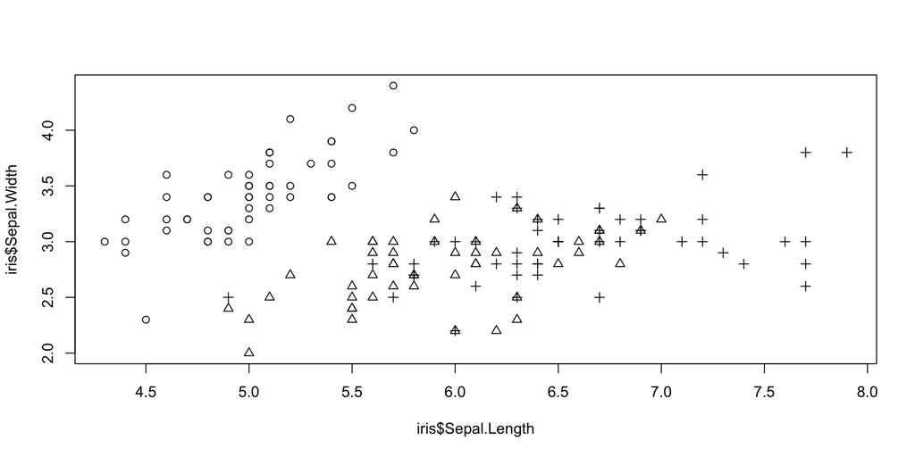

```r
plot( iris$Sepal.Length, iris$Sepal.Width, pch=symbol )
```

## Additional Customizations

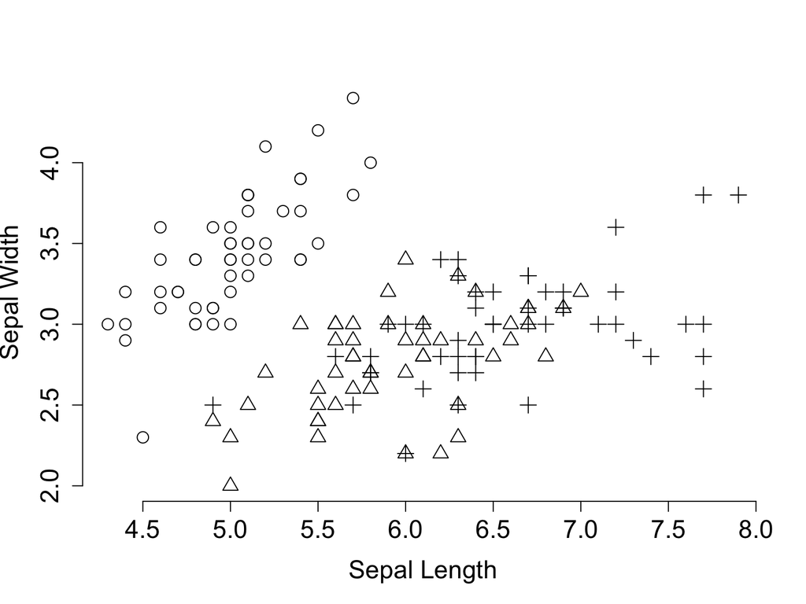

```r
plot( Sepal.Width ~ Sepal.Length, data = iris,
      pch = symbol, bty="n", cex=1.5, cex.axis=1.5, cex.lab = 1.5,
      xlab="Sepal Length", ylab="Sepal Width")
```

# Color Spaces

## Named Colors

In `R`, there are 657 different *named* colors accessable through the function `colors()`.

```r
sample( colors(), size=5, replace = FALSE )
```

```
[1] "orange4"    "sienna1"    "pink1"      "orangered2" "maroon2"
```

```r
raw_colors <- sample( colors(), size=3, replace=FALSE)
colors <- raw_colors[ symbol ]
colors
```

```
  [1] "grey75"    "grey75"    "grey75"    "grey75"    "grey75"    "grey75"
  [7] "grey75"    "grey75"    "grey75"    "grey75"    "grey75"    "grey75"
 [13] "grey75"    "grey75"    "grey75"    "grey75"    "grey75"    "grey75"
 [19] "grey75"    "grey75"    "grey75"    "grey75"    "grey75"    "grey75"
 [25] "grey75"    "grey75"    "grey75"    "grey75"    "grey75"    "grey75"
 [31] "grey75"    "grey75"    "grey75"    "grey75"    "grey75"    "grey75"
 [37] "grey75"    "grey75"    "grey75"    "grey75"    "grey75"    "grey75"
 [43] "grey75"    "grey75"    "grey75"    "grey75"    "grey75"    "grey75"
 [49] "grey75"    "grey75"    "palegreen" "palegreen" "palegreen" "palegreen"
 [55] "palegreen" "palegreen" "palegreen" "palegreen" "palegreen" "palegreen"
 [61] "palegreen" "palegreen" "palegreen" "palegreen" "palegreen" "palegreen"
 [67] "palegreen" "palegreen" "palegreen" "palegreen" "palegreen" "palegreen"
 [73] "palegreen" "palegreen" "palegreen" "palegreen" "palegreen" "palegreen"
 [79] "palegreen" "palegreen" "palegreen" "palegreen" "palegreen" "palegreen"
 [85] "palegreen" "palegreen" "palegreen" "palegreen" "palegreen" "palegreen"
 [91] "palegreen" "palegreen" "palegreen" "palegreen" "palegreen" "palegreen"
 [97] "palegreen" "palegreen" "palegreen" "palegreen" "mistyrose" "mistyrose"
[103] "mistyrose" "mistyrose" "mistyrose" "mistyrose" "mistyrose" "mistyrose"
[109] "mistyrose" "mistyrose" "mistyrose" "mistyrose" "mistyrose" "mistyrose"
[115] "mistyrose" "mistyrose" "mistyrose" "mistyrose" "mistyrose" "mistyrose"
[121] "mistyrose" "mistyrose" "mistyrose" "mistyrose" "mistyrose" "mistyrose"
[127] "mistyrose" "mistyrose" "mistyrose" "mistyrose" "mistyrose" "mistyrose"
[133] "mistyrose" "mistyrose" "mistyrose" "mistyrose" "mistyrose" "mistyrose"
[139] "mistyrose" "mistyrose" "mistyrose" "mistyrose" "mistyrose" "mistyrose"
[145] "mistyrose" "mistyrose" "mistyrose" "mistyrose" "mistyrose" "mistyrose"
```

## Adding a Legend

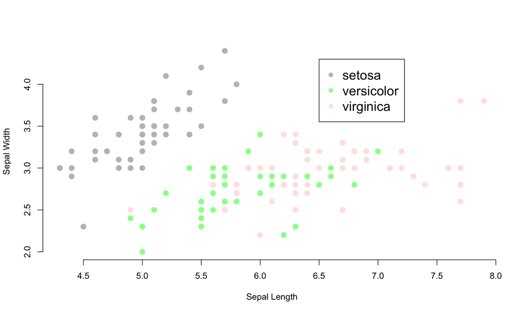

```r
plot( Sepal.Width ~ Sepal.Length, data = iris,
      col = colors, pch=20, bty="n", cex=2,
      xlab="Sepal Length", ylab="Sepal Width")
legend(6.5,4.3, pch=20, cex=1.5, col=raw_colors,legend=levels(iris$Species) )
```

## Hex Colors

Color spaces defined by:

- Red
- Green
- Blue

In base-16 no less:

> 0 1 2 3 4 5 6 7 8 9 A B C D E F

So for 2-digits, that is 256 distinct values for each color

> 00 → FF

## Hex Colors

Represented triplets of RRGGBB preceded by hashtag

```r
raw_colors <- c("#86cb92", "#8e4162", "#260F26")
colors <- raw_colors[ symbol ]
```

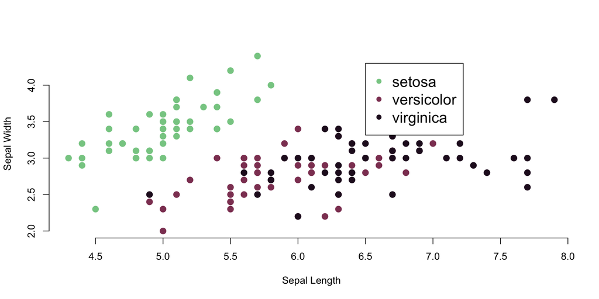

## Color Theme Generators

Google up something like “Color Theme Generator” and see what you find.

- One I use [coolors](https://coolors.co) to explore various themes.
- There is a built-in plugin for [Color Brewer](https://colorbrewer2.org) that makes it easy to integrate (we will use this in `ggplot` graphics).

## Color Brewer in R

|  | maxcolors | category | colorblind |
| --- | --- | --- | --- |
| BrBG | 11 | div | True |
| PiYG | 11 | div | True |
| PRGn | 11 | div | True |
| PuOr | 11 | div | True |
| RdBu | 11 | div | True |
| RdGy | 11 | div | False |
| RdYlBu | 11 | div | True |
| RdYlGn | 11 | div | False |
| Spectral | 11 | div | False |
| Accent | 8 | qual | False |

[output cut: 25 more lines]

```r
library(RColorBrewer)
display.brewer.all()
```

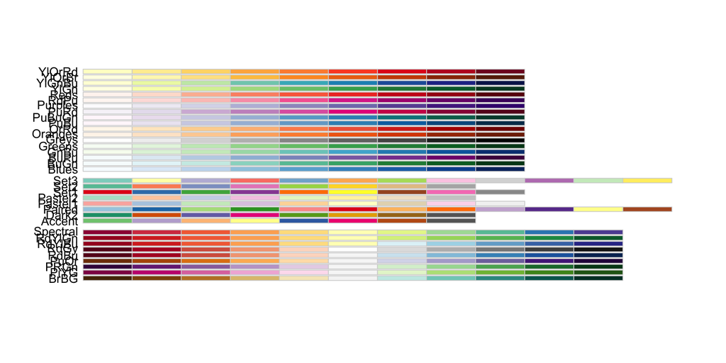

## Wes Anderson Palettes

This is a fun package that takes the colorspaces from Wes Anderson films for plotting.

[figure not shown]

```r
library( wesanderson )
names( wes_palettes )
```

```
 [1] "BottleRocket1"     "BottleRocket2"     "Rushmore1"
 [4] "Rushmore"          "Royal1"            "Royal2"
 [7] "Zissou1"           "Zissou1Continuous" "Darjeeling1"
[10] "Darjeeling2"       "Chevalier1"        "FantasticFox1"
[13] "Moonrise1"         "Moonrise2"         "Moonrise3"
[16] "Cavalcanti1"       "GrandBudapest1"    "GrandBudapest2"
[19] "IsleofDogs1"       "IsleofDogs2"       "FrenchDispatch"
[22] "AsteroidCity1"     "AsteroidCity2"     "AsteroidCity3"
```

```r
wes_palettes$Zissou1
```

```
[1] "#3B9AB2" "#78B7C5" "#EBCC2A" "#E1AF00" "#F21A00"
```

# Categorical Data

## Categorical Data

|  | Sepal.Length | Sepal.Width | Petal.Length | Petal.Width | Species |
| --- | --- | --- | --- | --- | --- |
| 1 | 5.1 | 3.5 | 1.4 | 0.2 | setosa |
| 2 | 4.9 | 3 | 1.4 | 0.2 | setosa |
| 3 | 4.7 | 3.2 | 1.3 | 0.2 | setosa |
| 4 | 4.6 | 3.1 | 1.5 | 0.2 | setosa |
| 5 | 5 | 3.6 | 1.4 | 0.2 | setosa |
| 6 | 5.4 | 3.9 | 1.7 | 0.4 | setosa |
| 7 | 4.6 | 3.4 | 1.4 | 0.3 | setosa |
| 8 | 5 | 3.4 | 1.5 | 0.2 | setosa |
| 9 | 4.4 | 2.9 | 1.4 | 0.2 | setosa |
| 10 | 4.9 | 3.1 | 1.5 | 0.1 | setosa |

[output cut: 140 more lines]

## Mean Sepal Length, by Species

```r
mu.Setosa <- mean( iris$Sepal.Length[ iris$Species == "setosa" ])
mu.Versicolor <- mean( iris$Sepal.Length[ iris$Species == "versicolor" ])
mu.Virginica <- mean( iris$Sepal.Length[ iris$Species == "virginica" ])

meanSepalLength <- c( mu.Setosa, mu.Versicolor, mu.Virginica )
meanSepalLength
```

```
[1] 5.006 5.936 6.588
```

## The BarPlot

Plotting quantitative data as a magnitude or amount.

```r
meanSepalLength <- by( iris$Sepal.Length, iris$Species, mean )
meanSepalLength
```

```
iris$Species: setosa
[1] 5.006
------------------------------------------------------------
iris$Species: versicolor
[1] 5.936
------------------------------------------------------------
iris$Species: virginica
[1] 6.588
```

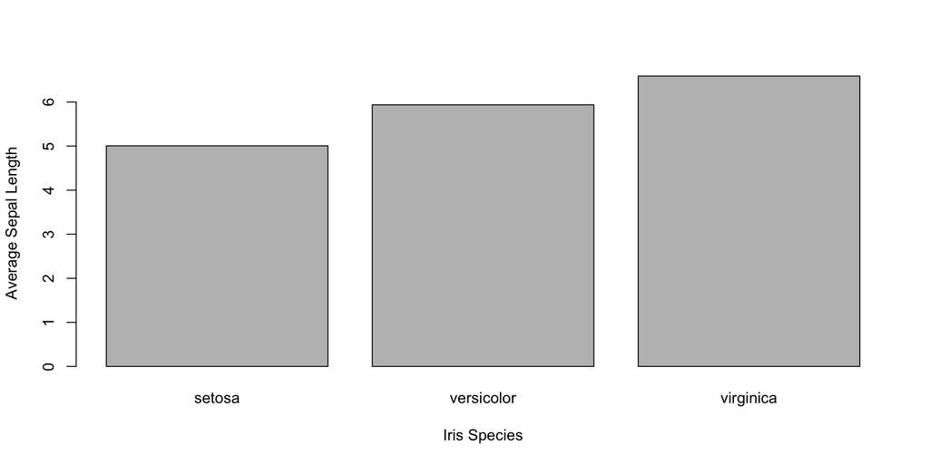

```r
barplot( meanSepalLength,
         xlab = "Iris Species",
         ylab = "Average Sepal Length")
```

## Boxplot - Information Dense

A boxplot contains a high amount of information content and is appropriate when the groupings on the x-axis are categorical. For each category, the graphical representation includes:

- The median value for the raw data
- A box indicating the area between the first and third quartile (e.g,. the values enclosing the 25% - 75% of the data). The top and bottoms are often referred to as the *hinges* of the box.
- A notch (if requested), represents confidence around the estimate of the median.
- Whiskers extending out to shows $\pm 1.5 * IQR$ (the Inner Quartile Range)
- Any points of the data that extend beyond the whiskers are plot as points.

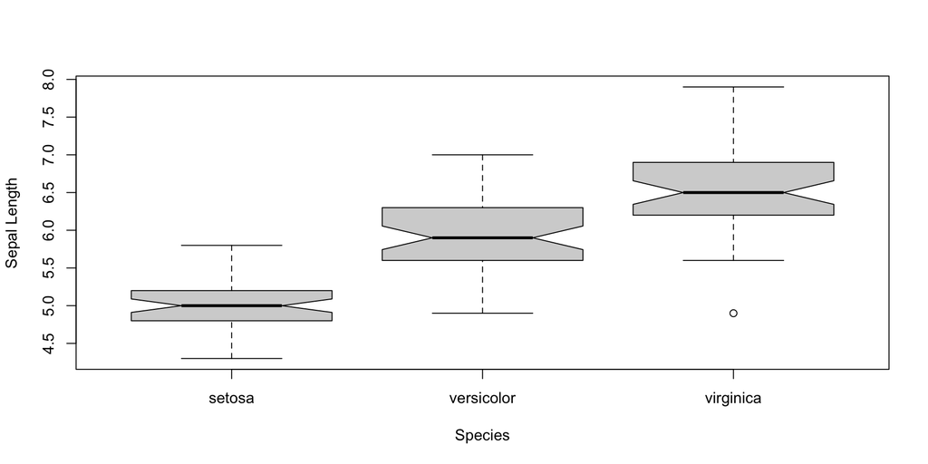

```r
boxplot( Sepal.Length ~ Species, data=iris,
         notch=TRUE, ylab="Sepal Length")
```

# Overrlaying Text

## Textifying Your Plot

```r
cor <- cor.test( iris$Sepal.Length, iris$Sepal.Width )
cor
```

```
    Pearson's product-moment correlation

data:  iris$Sepal.Length and iris$Sepal.Width
t = -1.4403, df = 148, p-value = 0.1519
alternative hypothesis: true correlation is not equal to 0
95 percent confidence interval:
 -0.27269325  0.04351158
sample estimates:
       cor
-0.1175698
```

```r
cor.text <- paste( "r = ", format( cor$estimate, digits=4),
                   "; P = ", format( cor$p.value, digits=4 ),
                   sep="" )
cor.text
```

```
[1] "r = -0.1176; P = 0.1519"
```

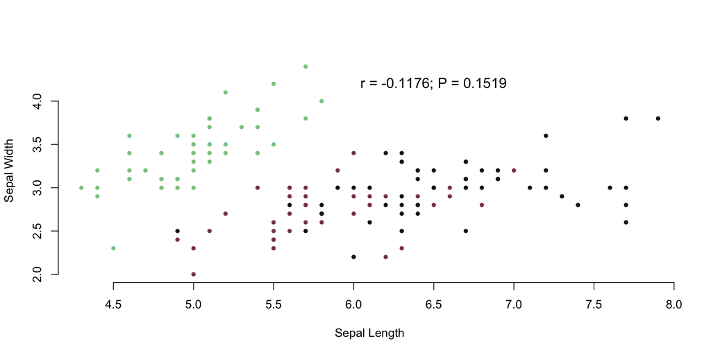

```r
plot( Sepal.Width ~ Sepal.Length, data = iris,
      col=colors,
      pch=20,
      bty="n",
      xlab="Sepal Length", ylab="Sepal Width")
text( 6.5, 4.2, cor.text, cex=1.2 )
```

## Questions

If you have any questions, please feel free to post to the [Canvas](https://canvas.vcu.edu) discussion board for the class, or drop me an email.

[Dyerlab](https://dyerlab.org)